# M3P Data Analysis

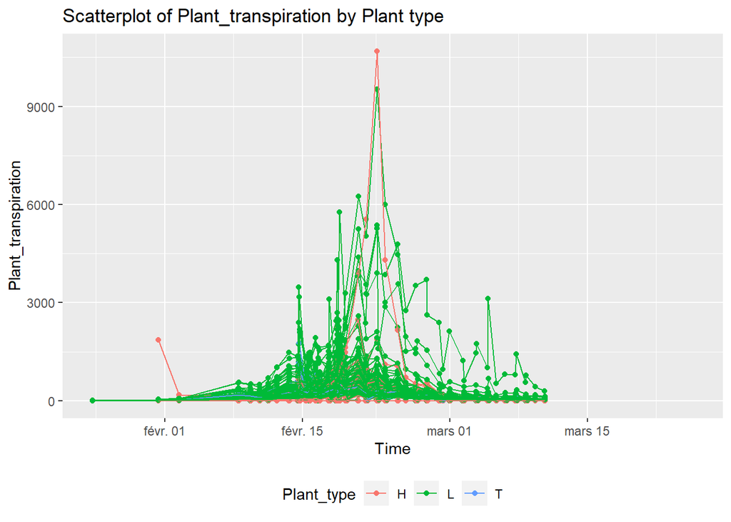

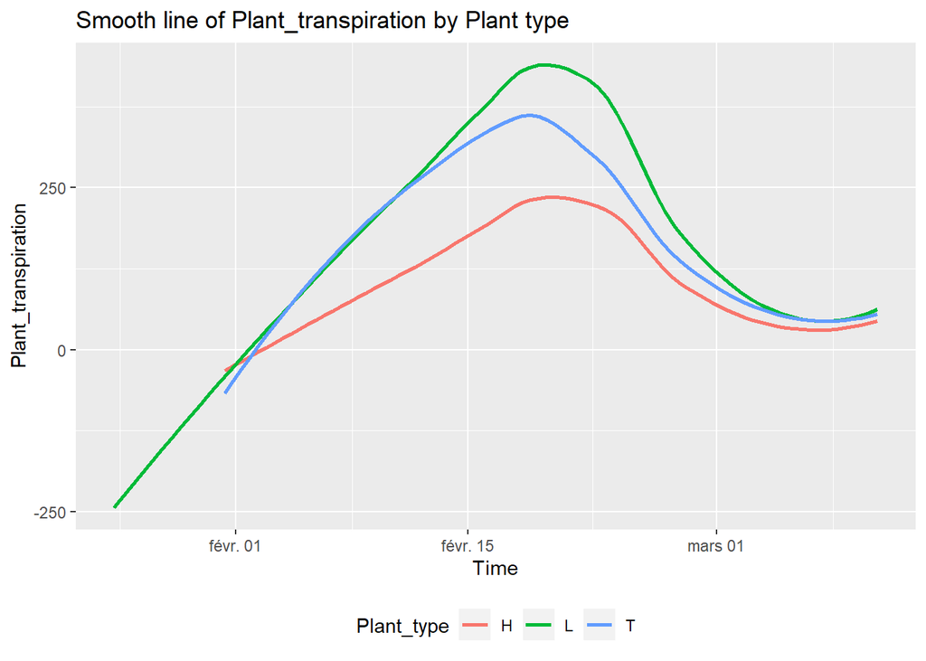

```r
plot_scatter_with_smooth(timeseries_Plant_transpiration, variables_t[5])
```

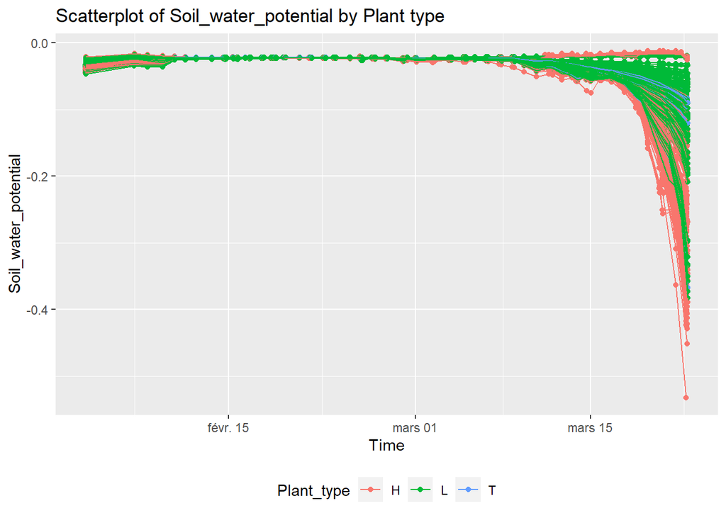

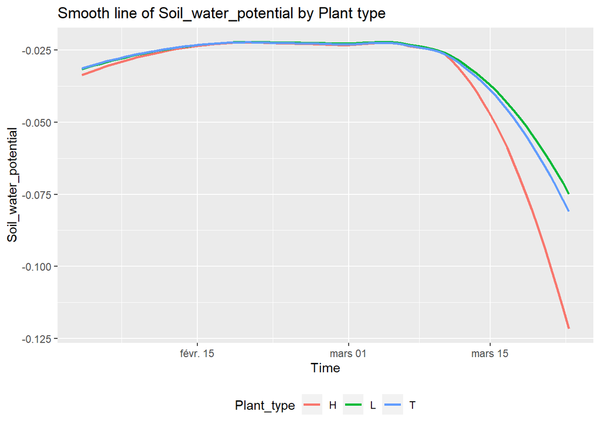

```r
plot_scatter_with_smooth(timeseries_Soil_water_potential, variables_t[6])
```

```r
# Problem for water timeseries data
```

Scatter plots for all genotypes by water treatment

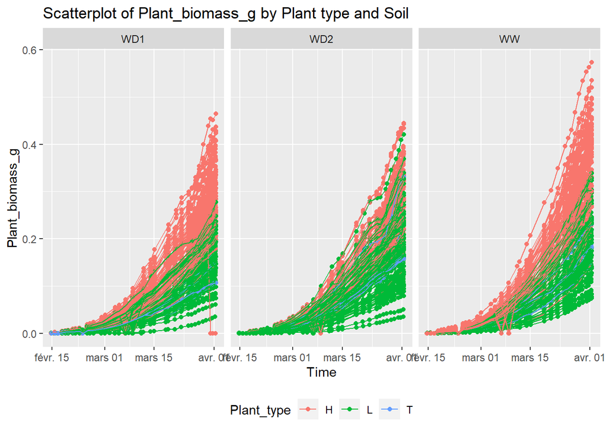

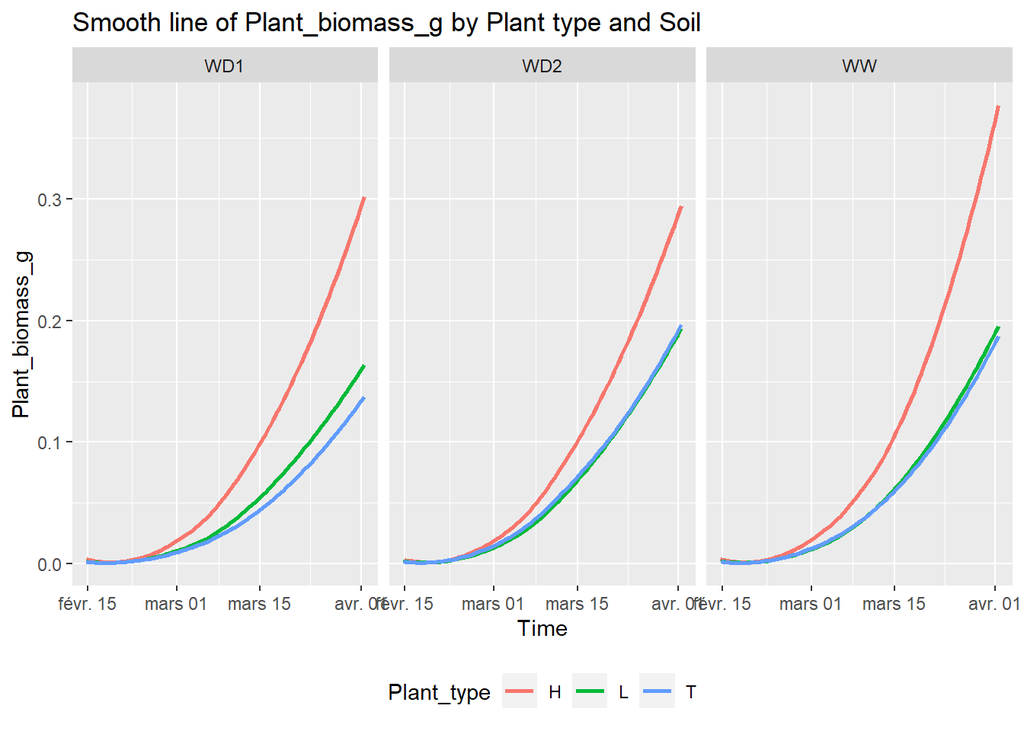

```r
plot_scatter_with_smooth_water(timeseries, variables_t[1])
```

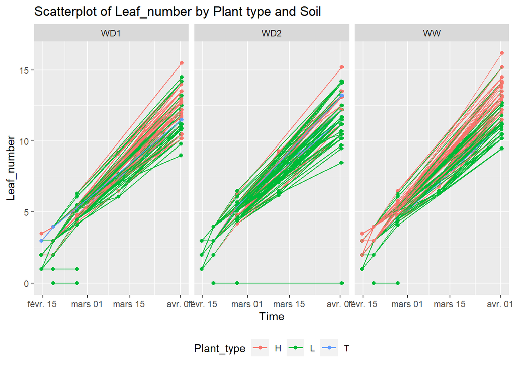

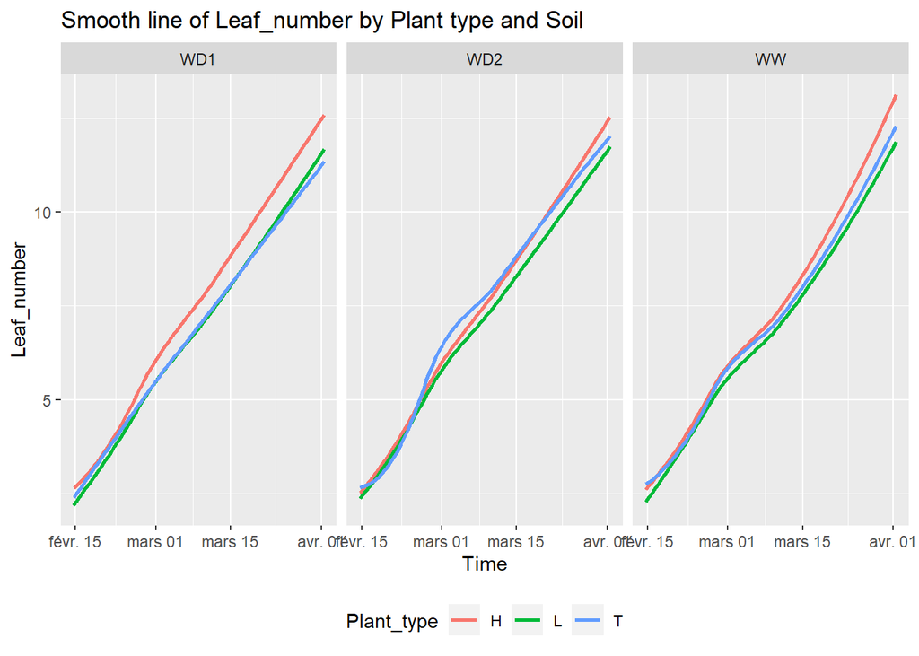

```r
plot_scatter_with_smooth_water(timeseries_Leaf_number, variables_t[2])
```

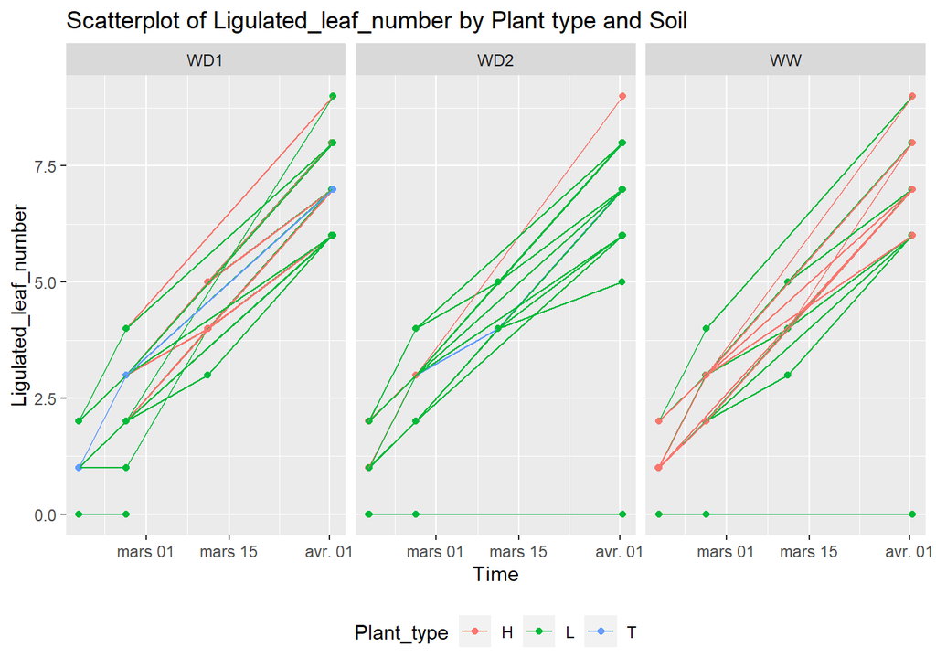

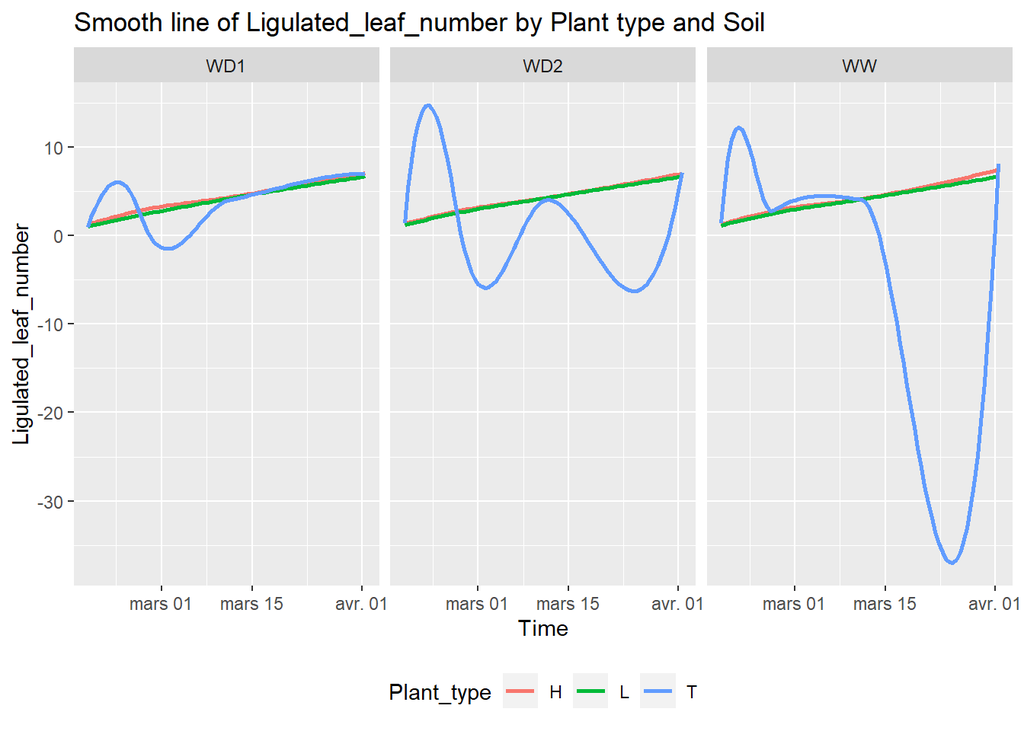

```r
plot_scatter_with_smooth_water(timeseries_Ligulated_leaf_number, variables_t[3])
```

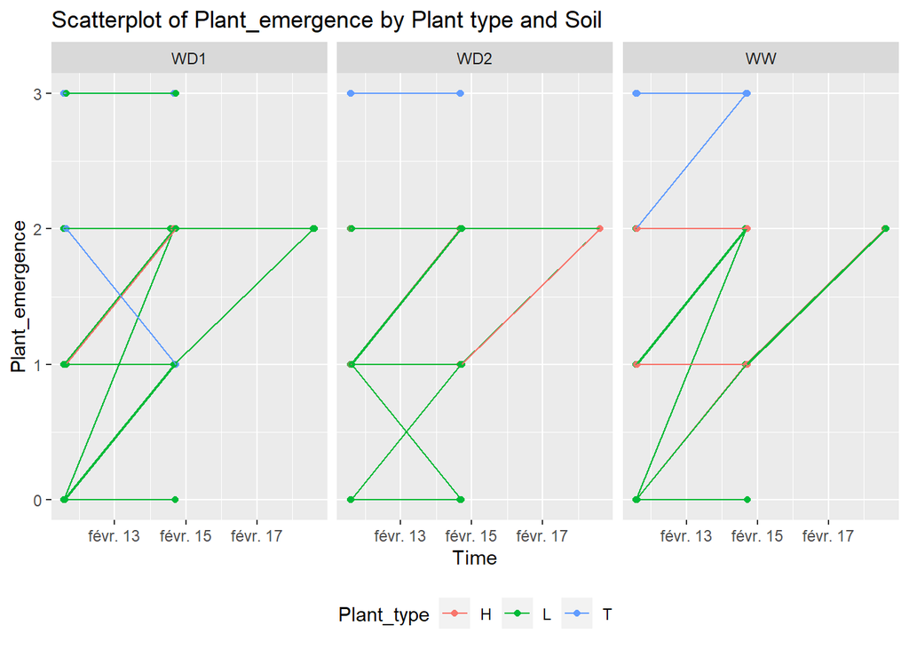

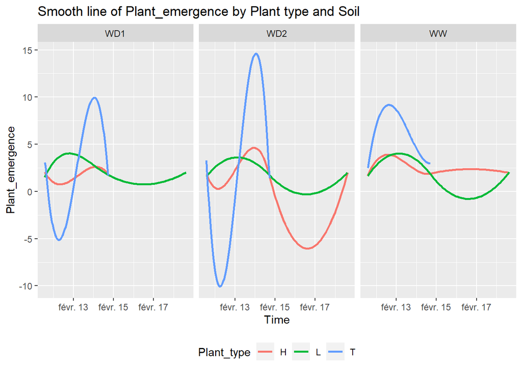

```r
plot_scatter_with_smooth_water(timeseries_Plant_emergence, variables_t[4])
```

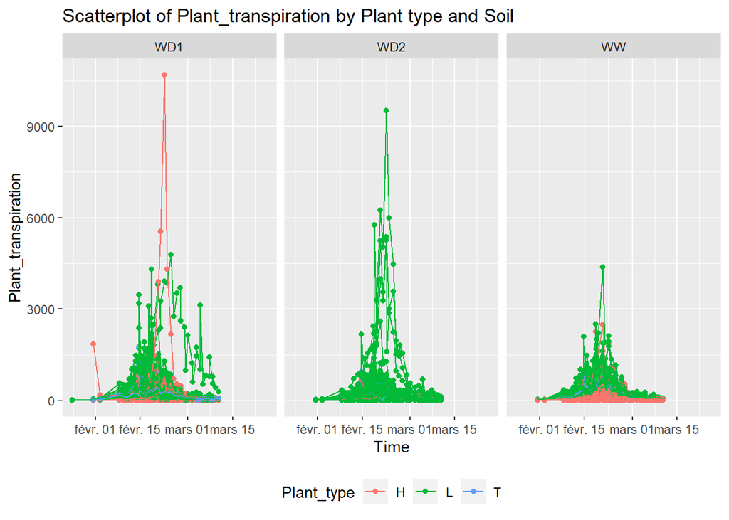

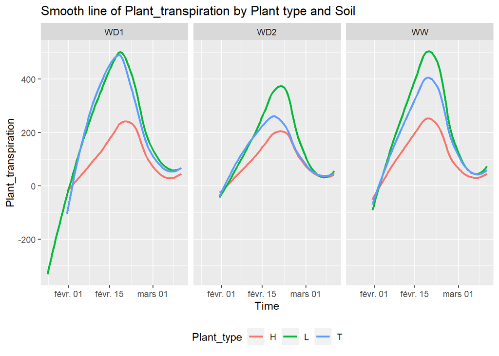

```r
plot_scatter_with_smooth_water(timeseries_Plant_transpiration, variables_t[5])
```

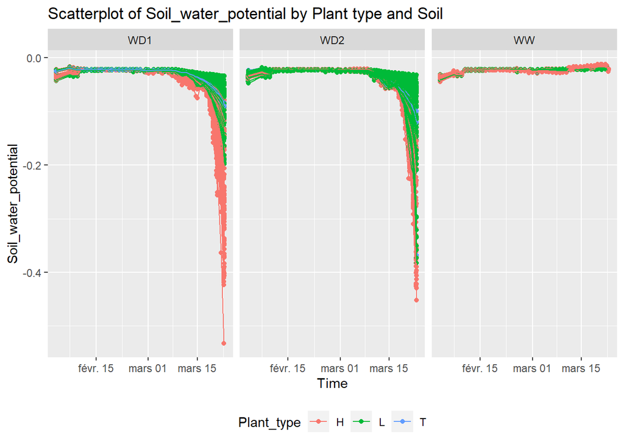

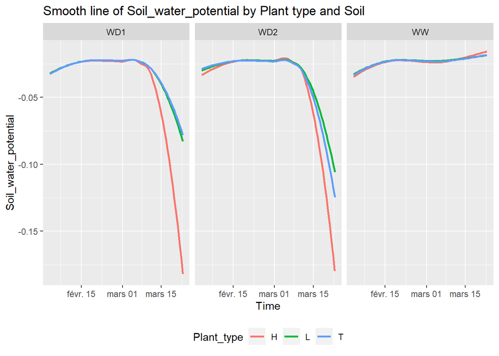

```r
plot_scatter_with_smooth_water(timeseries_Soil_water_potential, variables_t[6])
```

```r
# Problem for water timeseries data
```

## B. Exploration of the S_timeseries dataframe

Scatter plots by Genotype

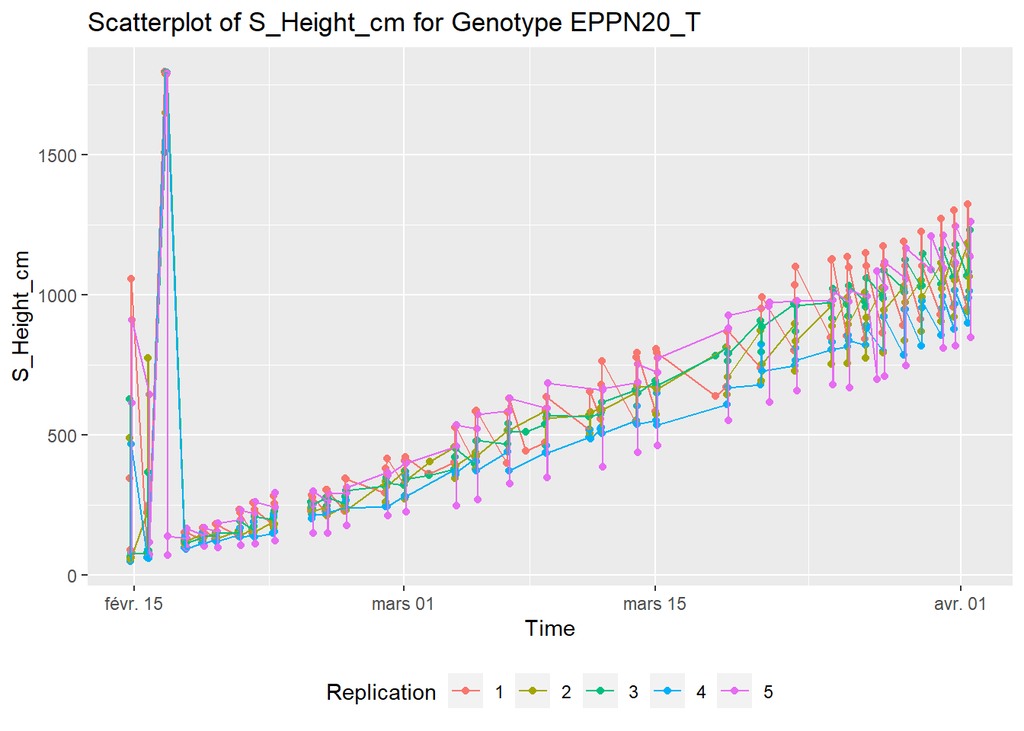

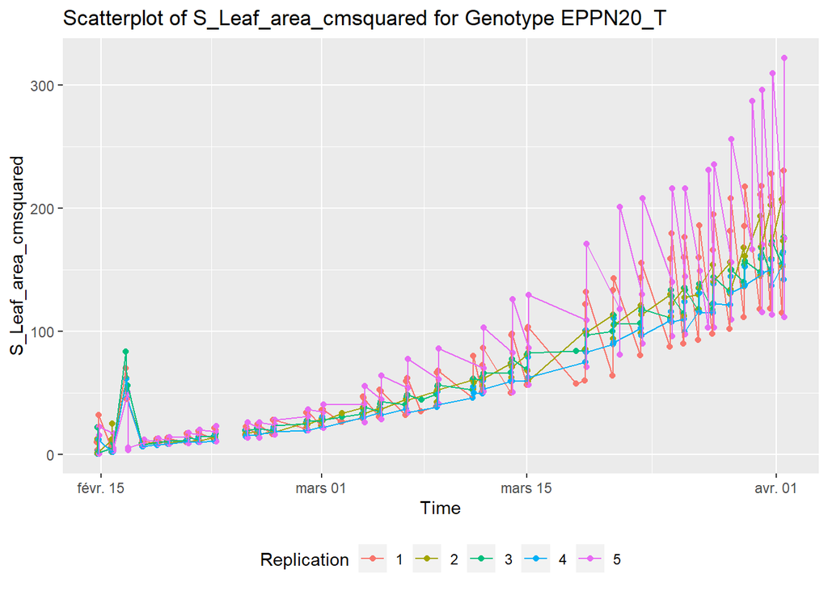

```r
plot_scatter_by_genotype(S_timeseries, variables_S, "EPPN20_T")
```

Scatterplots for all genotypes by Plant type (Hybride, Line, EPPN20_T) with smooth line.

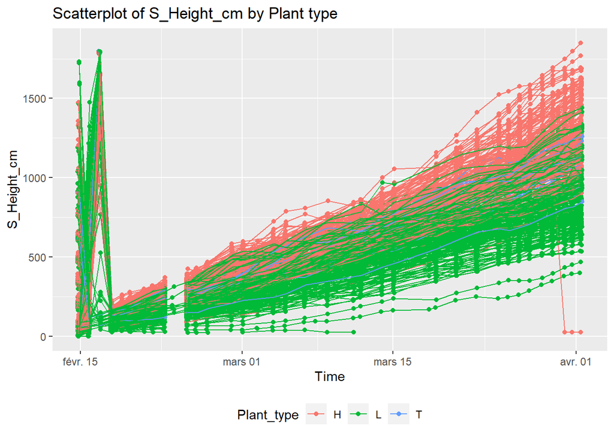

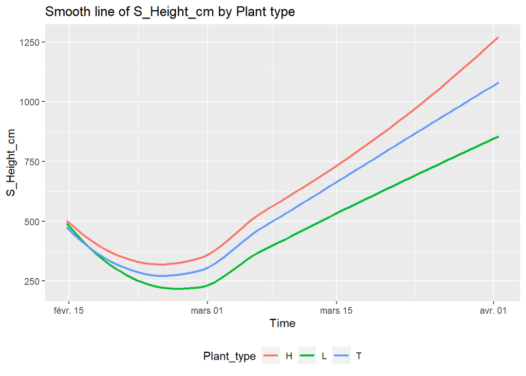

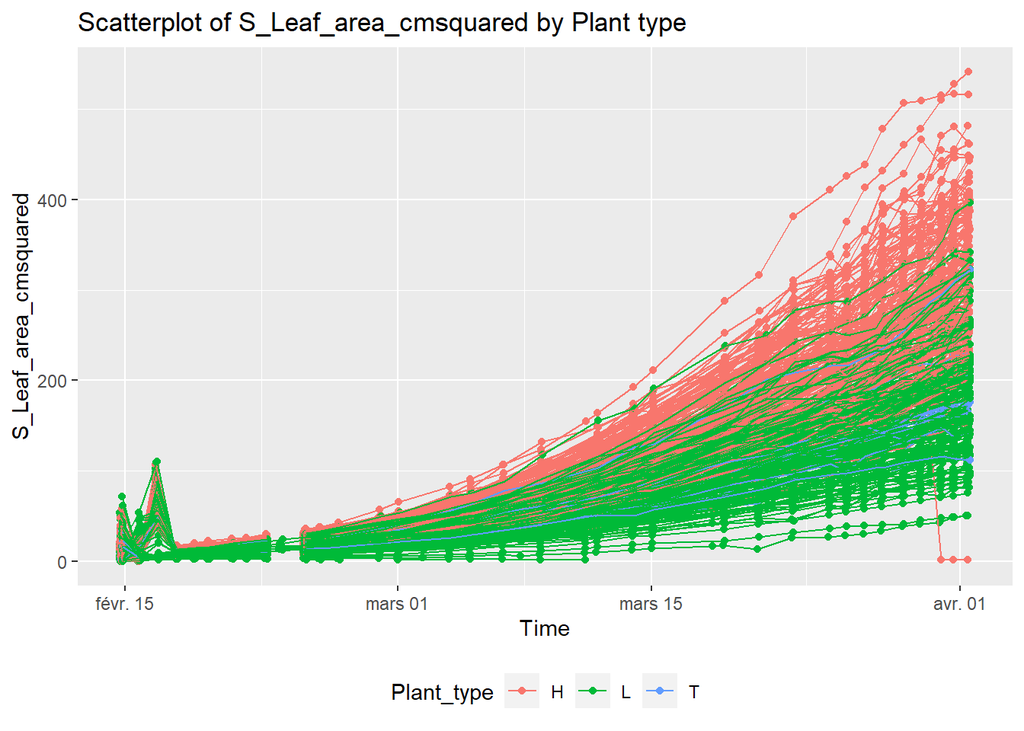

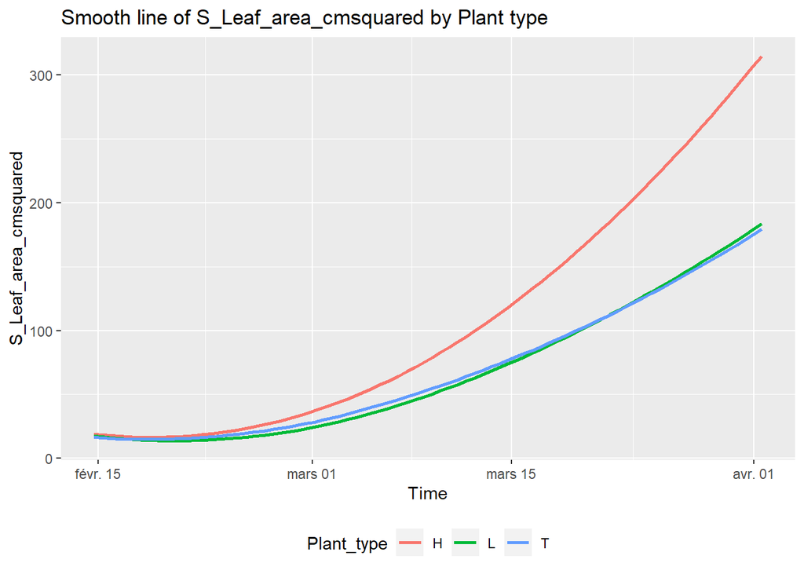

```r
plot_scatter_with_smooth(S_timeseries, variables_S)
```

Scatter plots for all genotypes by water treatment

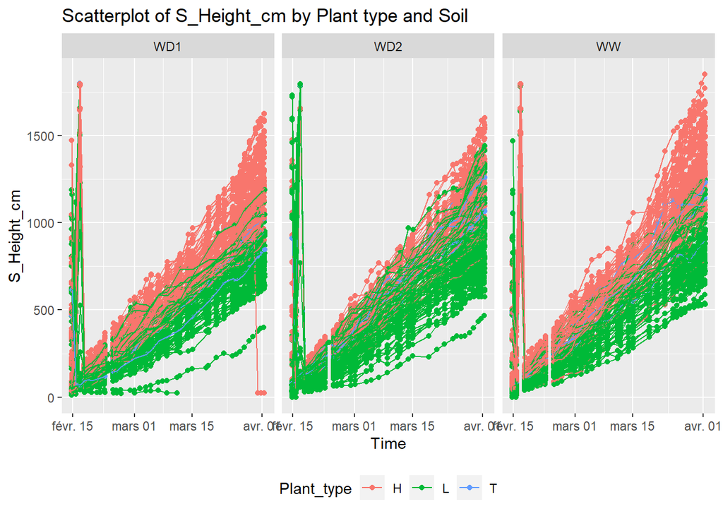

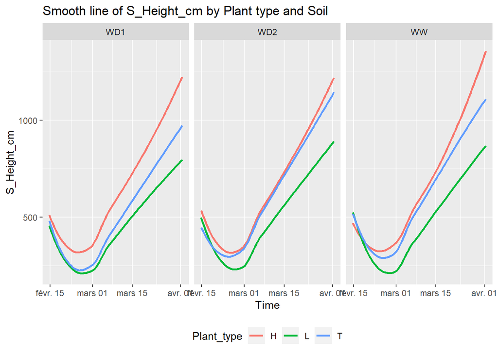

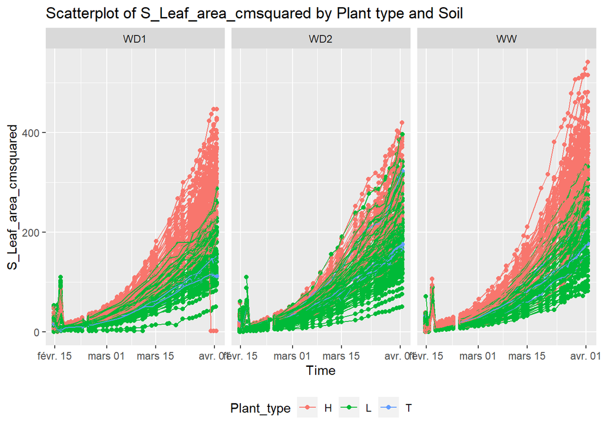

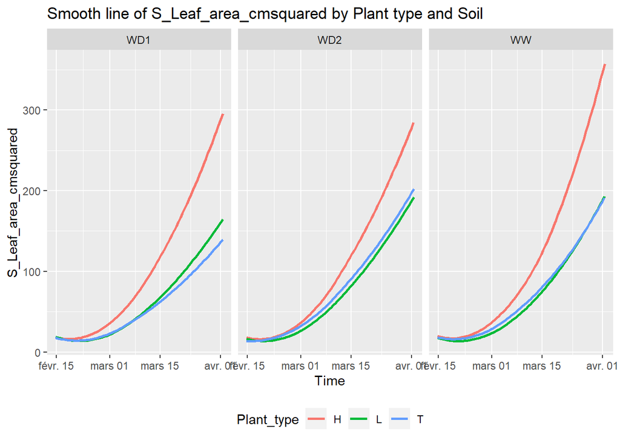

```r
plot_scatter_with_smooth_water(S_timeseries, variables_S)
```

## C. Exploration of the T_timeseries dataframe

Scatter plots by Genotype

```r
print(paste0("No data for", platform))
```

```
## [1] "No data forM3P"
```

Scatterplots for all genotypes by Plant type (Hybride, Line, EPPN20_T) with smooth line.

```r
print(paste0("No data for", platform))
```

```
## [1] "No data forM3P"
```

Scatter plots for all genotypes by water treatment

```r
print(paste0("No data for", platform))
```

```
## [1] "No data forM3P"
```